# Topic 5 Lab

Xue (Tracy) Feng

## Preparation

```r
# Load packages used in this session of R
library(tidyverse)
library(knitr)
library(tidytext)
# library(tm.plugin.webmining)
# library(purrr)
library("sentimentr")

# As needed, set path to folder where data is located.
opts_knit$set(root.dir = "C:/Users/Xue Feng/Desktop/OPIM606/Lab5")
```

The `sentimentr` package includes several text data sets. For this exercise use the “Crowdflower” data. This data set contains 8,937 tweets about products. It also contains a sentiment score for each tweet, a score produced via automated sentiment analysis.

Access this data by installing the `sentimentr` package, then loading it via `library(sentiment)` and (for convenience) creating a named data object (e.g., `rev = sentimentr::crowdflower_products`).

### (a) Calculate the number of tweets that include the terms “Apple” or “Android”

```r
value = str_detect(rev$text, pattern = "Apple|Android")
sum(value, na.rm = TRUE)
```

```
## [1] 2172
```

### (b) In cleaning the data, links were cut and a placeholder was inserted (“{link}”). Mentions were replaced with “@mention”. Remove these terms from the dataset.

```r
rev2 = rev %>%
  mutate(text = str_remove_all(text, "\\{\\w+\\}")) %>%
  mutate(text = str_remove_all(text, "@mention"))

# gg contains row numbers for all lines with the phrase
gg = str_which(rev$text, pattern = "\\{")
# first line of the original text
rev[gg[1],]
```

```
##    sentiment
## 1:         0
##                                                                                                 text
## 1: Attn: All #SXSW frineds, @mention Register for #GDGTLive and see Cobra iRadar for Android. {link}
```

```r
# first line of the updated text
rev2[gg[1],]
```

```
##    sentiment
## 1:         0
##                                                                                   text
## 1: Attn: All #SXSW frineds,  Register for #GDGTLive and see Cobra iRadar for Android.
```

### (c) The tweets have been analyzed for sentiment (the “sentiment” variable in the data set). Create a function that calculates the proportion of tweets that mention a given term that are positive (sentiment equals 1) . Implement this function for the words “Apple”, “Android” and “Google”

```r
getPosProportion = function (word) {
  # count of tweet that contains the word
  ttCount <- rev2 %>%
    filter(str_detect(text, pattern = word)) %>%
    count()

  # count of tweet that contains the word && positive
  ttPosCount <- rev2 %>%
    filter(str_detect(text, pattern = word)) %>%
    filter(sentiment == 1) %>%
    count()

  return(ttPosCount / ttCount)
}

res <-
  data.frame(
    getPosProportion("Apple"),
    getPosProportion("Android"),
    getPosProportion("Google")
  )
colnames(res) <- c('Apple', 'Android', 'Google')
print(res)
```

```
##       Apple   Android    Google
## 1 0.3939045 0.3272311 0.2792882
```

### (d) Create a word count for the negative sentiment tweets (those coded as sentiment equal to -1.0). Show the most common words.

```r
negWordCount <- rev2 %>%
  filter(sentiment == -1) %>%
  unnest_tokens(word, text) %>%
  count(word, sort = TRUE)

head(negWordCount, 10)
```

```
##       word   n
##  1:   sxsw 584
##  2:    the 311
##  3:     to 256
##  4:   ipad 191
##  5:   quot 175
##  6:     is 160
##  7: iphone 158
##  8:      a 154
##  9: google 150
## 10:     at 143
```

### (e) Create a word count for the negative sentiment tweets (those coded as sentiment equal to -1.0) with stop words removed. Show the most common words.

#### Since *quot* is not particularly informative, delete it as a stop word. (Use `anti_join(rbind("quot", tidytext::stop_words))` at the stop words stage.)

```r
negStopWord <- rev2 %>%
  filter(sentiment == -1) %>%
  unnest_tokens(word, text) %>%
  anti_join(rbind("quot", tidytext::stop_words)) %>%
  count(word, sort = T)

head(negStopWord, 10)
```

```
##        word   n
##  1:    sxsw 584
##  2:    ipad 191
##  3:  iphone 158
##  4:  google 150
##  5:      rt 138
##  6:   apple 115
##  7:       2  73
##  8:     app  60
##  9:   store  46
## 10: circles  34
```

### (f) Show a word cloud for the negative sentiment tweets (those coded as sentiment equal to -1.0) with stopwords removed.

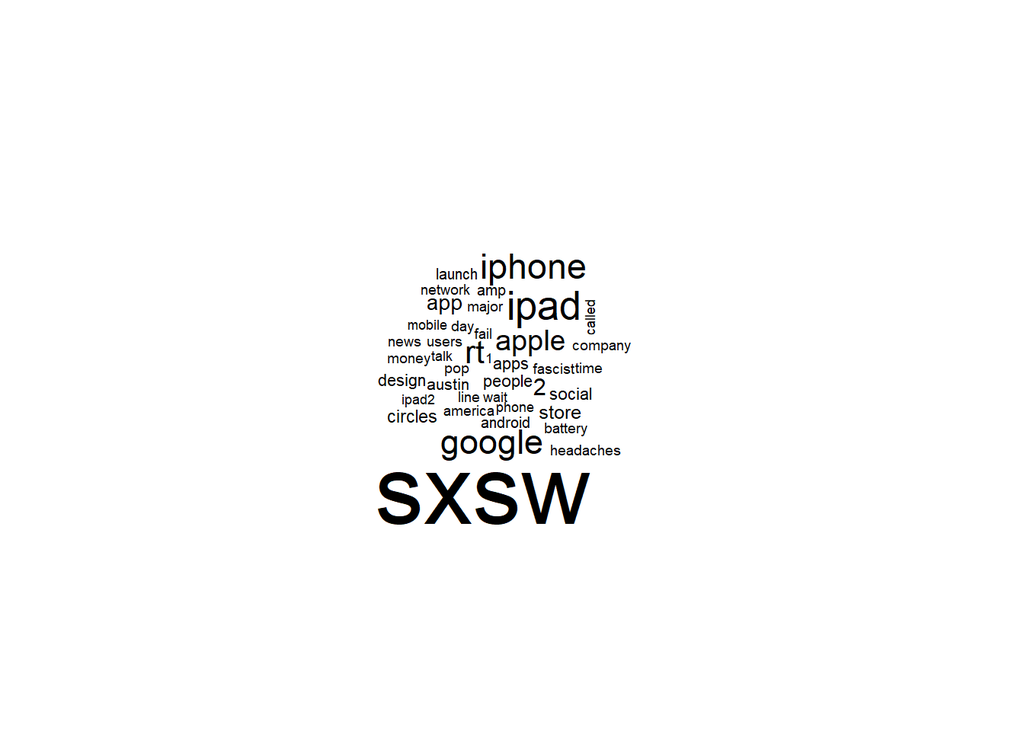

```r
negStopWord %>%
  with(wordcloud::wordcloud(word, n, max.words = 40))
```

### (g) Show a word cloud for the positive sentiment tweets (those coded as sentiment equal to 1.0) with stopwords removed.

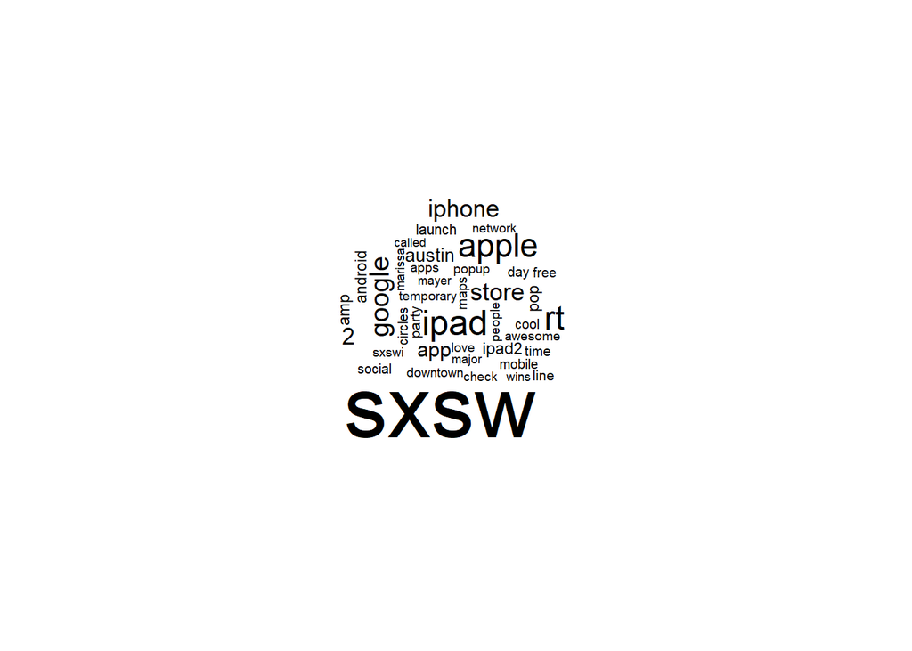

```r
posStopWord <- rev2 %>%
  filter(sentiment == 1) %>%
  unnest_tokens(word, text) %>%
  anti_join(rbind("quot", tidytext::stop_words)) %>%
  count(word, sort = T) %>%
  with(wordcloud::wordcloud(word, n, max.words = 40))
```

### (h) We are interested in finding words that are most distinctive in each sentiment group among tweets mentioning Apple.

#### We’re going to count the words, grouped by sentiment. To do this, use `count(sentiment, word, sort = TRUE)` which will count the word usage broken into sentiment categories. Display the top 25 terms sorted by tf-idf in descending order.

```r
# Word count by sentiment
Tweet_Words <- rev2 %>%
  # Get all tweets mentioning Apple using filter()
  filter(str_detect(text, pattern = "Apple")) %>%
  unnest_tokens(word, text) %>%
  anti_join(rbind("quot", tidytext::stop_words)) %>%
  count(sentiment, word, sort = TRUE)

# Total words by sentiment
Total_Words <- Tweet_Words %>%
  group_by(sentiment) %>%
  summarize(total = sum(n),
            .groups = 'drop')

# Join word count and total words
Tweet_Words <-
  left_join(Tweet_Words,
            Total_Words)

# show fist 15 rows
Tweet_Words[1:15]
```

```
##     sentiment   word    n total
##  1:         0   sxsw 1064  9000
##  2:         0  apple 1003  9000
##  3:         1   sxsw  765  6563
##  4:         1  apple  727  6563
##  5:         0  store  675  9000
##  6:         1  store  414  6563
##  7:         0 austin  339  9000
##  8:         0     rt  328  9000
##  9:         0    pop  305  9000
## 10:         1     rt  228  6563
## 11:         0   ipad  220  9000
## 12:         0      2  195  9000
## 13:         1    pop  180  6563
## 14:         1   ipad  171  6563
## 15:         1 austin  160  6563
```

```r
# Apply tf-idf function to
Tweet_Words <- Tweet_Words %>%
  bind_tf_idf(word, sentiment, n)

# Display the top 25 terms sorted by tf-idf in descending order
Tweet_Words %>%
  select(-total) %>%
  arrange(desc(tf_idf)) %>%
  slice(1:25)
```

```
##     sentiment         word  n          tf       idf      tf_idf
##  1:        -1      fascist 13 0.013584117 1.0986123 0.014923678
##  2:        -1    classiest  8 0.008359457 1.0986123 0.009183802
##  3:        -1      elegant  7 0.007314525 1.0986123 0.008035827
##  4:        -1      swisher  7 0.007314525 1.0986123 0.008035827
##  5:        -1         kara  6 0.006269592 1.0986123 0.006887851
##  6:        -1      america 14 0.014629049 0.4054651 0.005931569
##  7:        -1          rji  3 0.003134796 1.0986123 0.003443926
##  8:         0     congress 59 0.006555556 0.4054651 0.002658049
##  9:         1       begins 43 0.006551882 0.4054651 0.002656559
## 10:         1         wins 42 0.006399512 0.4054651 0.002594779
## 11:         0        rumor 53 0.005888889 0.4054651 0.002387739
## 12:        -1         1500  2 0.002089864 1.0986123 0.002295950
## 13:        -1  autocorrect  2 0.002089864 1.0986123 0.002295950
## 14:        -1 autocorrects  2 0.002089864 1.0986123 0.002295950
## 15:        -1      charity  2 0.002089864 1.0986123 0.002295950
## 16:        -1   collection  2 0.002089864 1.0986123 0.002295950
## 17:        -1  corporation  2 0.002089864 1.0986123 0.002295950
## 18:        -1          csr  2 0.002089864 1.0986123 0.002295950
## 19:        -1     decision  2 0.002089864 1.0986123 0.002295950
## 20:        -1       drives  2 0.002089864 1.0986123 0.002295950
## 21:        -1   egomaniacs  2 0.002089864 1.0986123 0.002295950
## 22:        -1       idiocy  2 0.002089864 1.0986123 0.002295950
## 23:        -1      iphones  2 0.002089864 1.0986123 0.002295950
## 24:        -1      janecek  2 0.002089864 1.0986123 0.002295950
## 25:        -1          mad  2 0.002089864 1.0986123 0.002295950
##     sentiment         word  n          tf       idf      tf_idf
```

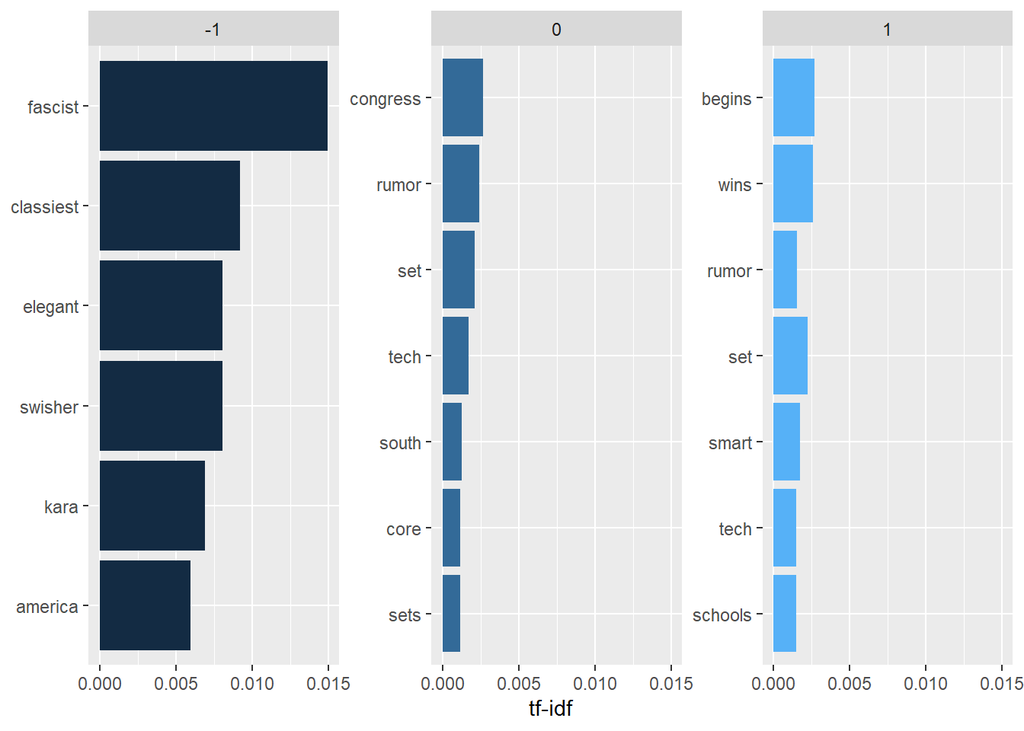

```r
# Visualize using ggplot
Tweet_Words %>%
  arrange(desc(tf_idf)) %>%
  mutate(word=factor(word,
                     levels = rev(unique(word)))) %>%
  group_by(sentiment) %>%
  top_n(6) %>%
  ungroup() %>%
ggplot(aes(word,tf_idf, fill = sentiment))+
  geom_col(show.legend = FALSE)+
  labs(x=NULL,y="tf-idf")+
  facet_wrap(~sentiment,scales = "free_y")+
  coord_flip()
```

### BONUS: find most common bigrams

```r
# Tokenization (bigrams)
rev2 %>%
  unnest_tokens(word,
                text,
                token = "ngrams",
                n = 2)
```

```
##         sentiment        word
##      1:        -1  wesley83 i
##      2:        -1      i have
##      3:        -1      have a
##      4:        -1        a 3g
##      5:        -1   3g iphone
##     ---
## 141036:         0 tests check
## 141037:         0    check in
## 141038:         0   in offers
## 141039:         0   offers at
## 141040:         0     at sxsw
```

```r
# Count the frequency of bigrams
Bigrams_Count <-  rev2 %>%
  unnest_tokens(word, text,
                # set argument to bigrams
                token = "ngrams",
                n = 2) %>%
  count(word, sort = TRUE)

# Show the most common bigrams
head(Bigrams_Count)
```

```
##           word    n
## 1:     at sxsw 1832
## 2:      ipad 2  941
## 3:    for sxsw  605
## 4: apple store  573
## 5:      pop up  571
## 6:      at the  450
```

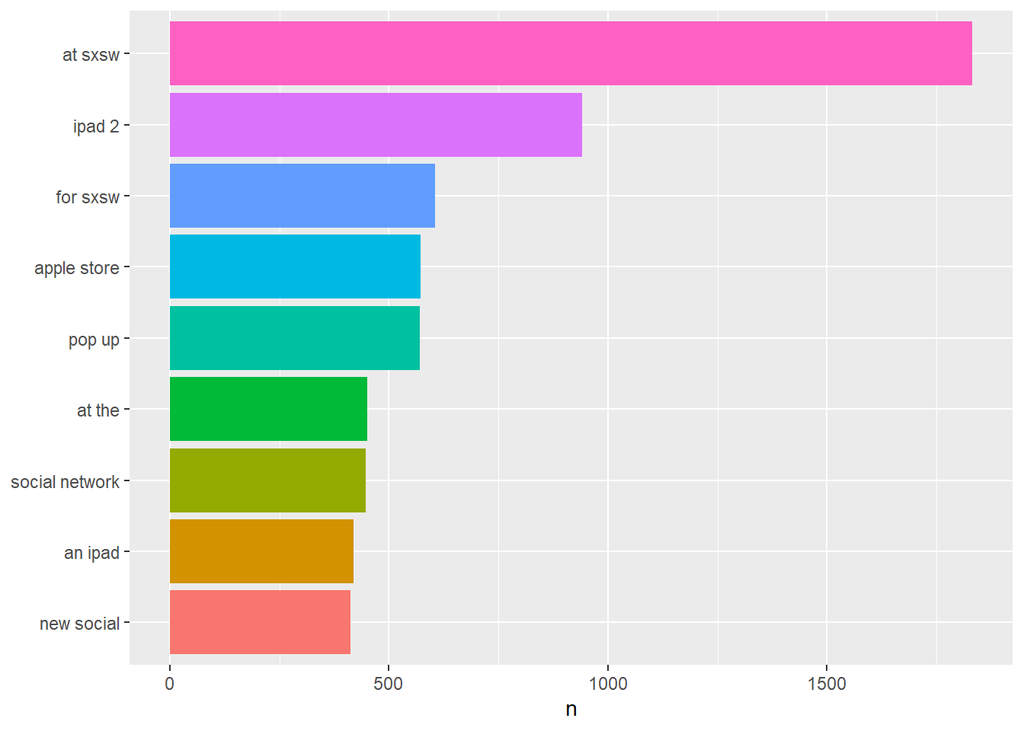

```r
# Visualize the most common bigrams
Bigrams_Count %>%
  filter(n > 400) %>%
  mutate(word = reorder(word, n)) %>%
  ggplot(aes(word, n, fill = word)) +
  geom_col() +
  xlab(NULL)+
  coord_flip()+
  theme(legend.position="none")
```